# 1. PROBLEM STATEMENT:-

1. The aim of this project is to investigate whether there is a relationship between happiness, alcohol consumption and GDP for countries across the world.
2. To study does alcohol consumption have a direct effect on happiness, irrelevant of country or location. If not, then what other factors in the data set have a relationship with the Happiness score?

# 2. OBJECTIVE:-

1. Look at the Happiness Scores
2. Look at the Human Development Index (HDI)
3. Look at the GDP PerCapita
4. Look at the Alcohol consumption per Capita
5. Find relationship between happiness and alcohol consumption
6. Find relationship between happiness and other factors in data set.

# BACKGROUND OF DATA SET:-

1. This data was collected from 122 countries across the world during 2016. Measured variables included alcohol consumption (for beer, wine and spirits individually) measured as liters consumed per average person, the Happiness Score (an index ranging from 0 to 10), and GDP (gross domestic production) percapita.
2. Countries with higher GDP are exponentially higher in their Happiness Scores.

# DATA DESCRIPTION:-

1.Country - Name of the Country 2.Region - Region the country belongs to 3.Hemisphere - Hemisphere of country 4.Happiness Score - A metric measured in 2016 by asking the sampled people the question: “How would you rate your happiness on a scale of 0 to 10 where 10 is the happiest” 5.HDI - Human Development Index by United Nations Development Program(Life expectancy + Education + standard of living) 6.GDP_PerCapita - Gross Domestic Product index 7.Beer_PerCapita - Liters (per capita) of beer consumption 8.Spirit_PerCapita - Liters (per capita) of spirit consumption 9.Wine_PerCapita - Liters (per capita) of wine consumption

# Loading the data set:-

```r
df <- read.csv("C:\\Users\\manis\\Desktop\\D21022-D21033 AML Dataset.csv",header=TRUE)
head(df)
```

```
##       Country         Region Hemisphere HappinessScore HDI GDP_PerCapita
## 1     Denmark Western Europe      north          7.526 928        53.579
## 2 Switzerland Western Europe      north          7.509 943        79.866
## 3     Iceland Western Europe      north          7.501 933        60.530
## 4      Norway Western Europe      north          7.498 951        70.890
## 5     Finland Western Europe      north          7.413 918        43.433
## 6      Canada  North America      north          7.404 922        42.349
##   Beer_PerCapita Spirit_PerCapita Wine_PerCapita
## 1            224               81            278
## 2            185              100            280
## 3            233               61             78
## 4            169               71            129
## 5            263              133             97
## 6            240              122            100
```

# Exploratory Data Analysis:-

3. Univariate Analysis
4. Bivariate Analysis
5. Anomaly Detection
6. Missing value imputation
7. Outlier analysis(If required)

#————————————————————- ## 3. UNIVARIATE ANALYSIS:- #————————————————————- # a. Summary

```r
summary(df)
```

```
##    Country             Region           Hemisphere        HappinessScore
##  Length:122         Length:122         Length:122         Min.   :3.069
##  Class :character   Class :character   Class :character   1st Qu.:4.528
##  Mode  :character   Mode  :character   Mode  :character   Median :5.542
##                                                           Mean   :5.525
##                                                           3rd Qu.:6.477
##                                                           Max.   :7.526
##       HDI        GDP_PerCapita     Beer_PerCapita   Spirit_PerCapita
##  Min.   :351.0   Min.   :  1.029   Min.   :  1.00   Min.   :  1.0
##  1st Qu.:663.8   1st Qu.:  4.134   1st Qu.: 38.25   1st Qu.: 25.5
##  Median :757.5   Median : 12.016   Median :125.50   Median : 82.5
##  Mean   :740.9   Mean   : 91.483   Mean   :137.57   Mean   : 96.6
##  3rd Qu.:861.5   3rd Qu.: 41.990   3rd Qu.:224.75   3rd Qu.:142.5
##  Max.   :951.0   Max.   :953.000   Max.   :376.00   Max.   :373.0
##  Wine_PerCapita
##  Min.   :  1.0
##  1st Qu.:  5.0
##  Median : 16.0
##  Mean   : 66.6
##  3rd Qu.:112.8
##  Max.   :370.0
```

# Observation:

We have 3 categorical variables Country,Hemisphere and Region. And 6 numeric variables. But note that all these variables are on different scales. For eg:- Happiness score ranges from 0-10 ,where as Beer consumption is in liters. We have to standardize these variables to eliminate any type of bias.

# Summary of happiness score

```r
summary(df$HappinessScore)
```

```
##    Min. 1st Qu.  Median    Mean 3rd Qu.    Max.
##   3.069   4.528   5.542   5.525   6.477   7.526
```

# Observation:

Least happiness score is 3.069 and Highest is 7.526. Let us find which are those countries having least and highest happiness score and let’s see if we can find a relationship of them with Alcohol consumption.

# Finding out max and min happiness score

```r
high = subset(df,df$HappinessScore == max(df$HappinessScore))
low = subset(df,df$HappinessScore == min(df$HappinessScore))
print(high)
```

```
##   Country         Region Hemisphere HappinessScore HDI GDP_PerCapita
## 1 Denmark Western Europe      north          7.526 928        53.579
##   Beer_PerCapita Spirit_PerCapita Wine_PerCapita
## 1            224               81            278
```

```r
print(low)
```

```
##     Country                          Region Hemisphere HappinessScore HDI
## 122   Syria Middle East and Northern Africa      north          3.069 536
##     GDP_PerCapita Beer_PerCapita Spirit_PerCapita Wine_PerCapita
## 122         2.058              5               35             16
```

# Observation:

Looking at this Syria has lowest happiness score and Denmark has highest. Let’s see if these countries consume more alcohol or less.

# Finding out alcohol consumption in Denmark

```r
subset(df$Beer_PerCapita,df$Country == 'Denmark')
```

```
## [1] 224
```

```r
subset(df$Spirit_PerCapita,df$Country == 'Denmark')
```

```
## [1] 81
```

```r
subset(df$Wine_PerCapita,df$Country == 'Denmark')
```

```
## [1] 278
```

# Observation:

Looks like wine is consumed more in Denmark than other alcohols.

# Finding out alcohol consumption in Syria

```r
subset(df$Beer_PerCapita,df$Country == 'Syria')
```

```
## [1] 5
```

```r
subset(df$Spirit_PerCapita,df$Country == 'Syria')
```

```
## [1] 35
```

```r
subset(df$Wine_PerCapita,df$Country == 'Syria')
```

```
## [1] 16
```

# observation:

Syria doesn’t seem to be consuming alot of alcohol. This could be the reason for lowest happines score.

# Take Away:

1. For all the countries listed in this dataset, the lowest Happiness Score was obtained by Syria with a score of (3.06) and the highest was found to be Denmark with a score of (7.526).
2. By looking at the overall structure of the data, the average Happiness Score was 5.525 with an interquartile range of 1.949.
3. Alcohol consumption in Denmark was highest for wine.The other alcohol types was significantly higher than alcohol consumption in Syria.This may be due to the different drinking laws in the countries, as there is no age restriction for the consumption of alcohol in Denmark, while the legal drinking age for Syria is 21. From this comparison between the least and most happy countries there is evidence that greater alcohol consumption is correlated with increasing happiness.

# Let’s find out which country consumes most amount of alcohol and plot their happiness score.

```r
df$total_alcohol <- df$Beer_PerCapita + df$Spirit_PerCapita + df$Wine_PerCapita
```

```r
subset(df,df$total_alcohol == max(df$total_alcohol))
```

```
##           Country                     Region Hemisphere HappinessScore HDI
## 26 Czech Republic Central and Eastern Europe      north          6.596 885
##    GDP_PerCapita Beer_PerCapita Spirit_PerCapita Wine_PerCapita total_alcohol
## 26        18.484            361              170            134           665
```

# Observation:

Czech Republic consumes most amount of alcohol with happiness score as 6.596. Now the reason for consumption of most alcohol could be that cities in Czech republic are tourist destinations and also has extreme cold weather which could be one of the reasons for maximum consumption of alcohol.

Still we cannot comment on Happiness score without considering GDP and HDI in account.

# Let’s find the country having highest and lowest HDI

```r
df_hdi = subset(df,df$HDI==max(df$HDI))
df_hdi1 = subset(df,df$HDI==min(df$HDI))
print(df_hdi1)
```

```
##     Country             Region Hemisphere HappinessScore HDI GDP_PerCapita
## 114   Niger Sub-Saharan Africa      north          3.856 351           368
##     Beer_PerCapita Spirit_PerCapita Wine_PerCapita total_alcohol
## 114              3                2              1             6
```

```r
print(df_hdi)
```

```
##   Country         Region Hemisphere HappinessScore HDI GDP_PerCapita
## 4  Norway Western Europe      north          7.498 951         70.89
##   Beer_PerCapita Spirit_PerCapita Wine_PerCapita total_alcohol
## 4            169               71            129           369
```

# observation:

Norway has highest HDI. Also, there happiness score is good. whereas Niger has the lowest HDI with low Happiness score.

# Country having highest and lowest GDP

```r
df_gdp = subset(df,df$GDP_PerCapita==max(df$GDP_PerCapita))
df_gdp1 = subset(df,df$GDP_PerCapita==min(df$GDP_PerCapita))
print(df_gdp)
```

```
##     Country             Region Hemisphere HappinessScore HDI GDP_PerCapita
## 102 Senegal Sub-Saharan Africa      north          4.219 499           953
##     Beer_PerCapita Spirit_PerCapita Wine_PerCapita total_alcohol
## 102              9                1              7            17
```

```r
print(df_gdp1)
```

```
##      Country             Region Hemisphere HappinessScore HDI GDP_PerCapita
## 104 Zimbabwe Sub-Saharan Africa      south          4.193 532         1.029
##     Beer_PerCapita Spirit_PerCapita Wine_PerCapita total_alcohol
## 104             64               18              4            86
```

# Observation:

# b. Frequency Table

```r
table(df$HappinessScore)
```

```
##
## 3.069 3.303 3.484 3.622 3.666 3.695 3.739 3.763 3.856 3.866 3.907 3.916 3.956
##     1     1     1     1     1     1     1     1     1     1     1     1     1
## 3.974 4.028 4.073 4.121 4.156 4.193 4.217 4.219 4.236 4.252 4.272 4.276 4.324
##     1     1     1     1     1     1     1     1     1     1     1     1     1
## 4.356  4.36 4.362 4.459 4.513 4.574 4.635 4.655 4.795 4.871 4.875 4.907 5.033
##     1     1     1     1     1     1     1     1     1     1     1     1     1
## 5.045 5.061 5.121 5.123 5.129 5.145 5.151 5.155 5.161 5.163 5.177 5.185 5.245
##     1     1     1     1     1     1     1     1     1     1     1     1     1
## 5.279 5.291 5.303 5.389 5.488  5.51 5.517 5.528 5.538 5.546  5.56 5.648 5.658
##     1     1     1     1     1     1     1     1     1     1     1     1     1
## 5.743 5.768 5.802 5.813 5.822 5.835 5.856 5.897 5.919 5.921 5.956 5.976 5.977
##     1     1     1     1     1     2     1     1     1     1     1     1     1
## 5.987 5.992 6.068 6.078 6.084 6.168 6.218 6.269 6.324 6.361 6.375 6.474 6.478
##     1     1     1     1     1     1     1     1     1     1     1     1     1
## 6.481 6.488 6.545 6.573 6.596  6.65 6.701 6.705 6.725 6.739 6.778 6.871 6.907
##     1     1     1     1     1     1     1     1     1     1     1     1     1
## 6.929 6.952 6.994 7.087 7.104 7.119 7.267 7.291 7.313 7.334 7.339 7.404 7.413
##     1     1     1     1     1     1     1     1     1     1     1     1     1
## 7.498 7.501 7.509 7.526
##     1     1     1     1
```

# Observation:-

# a. Plotting Boxplot & Histogram numeric variables

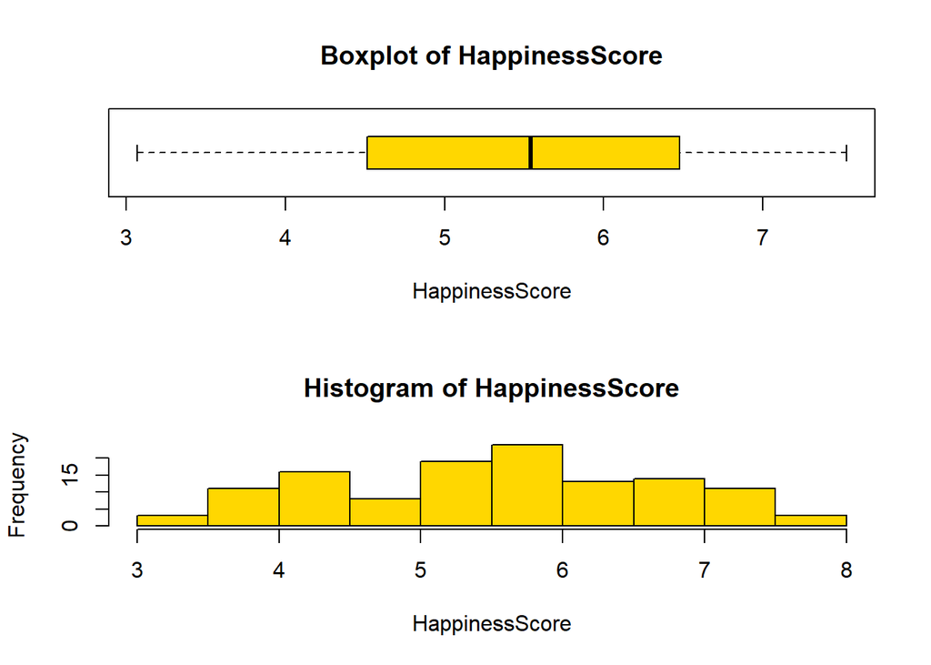

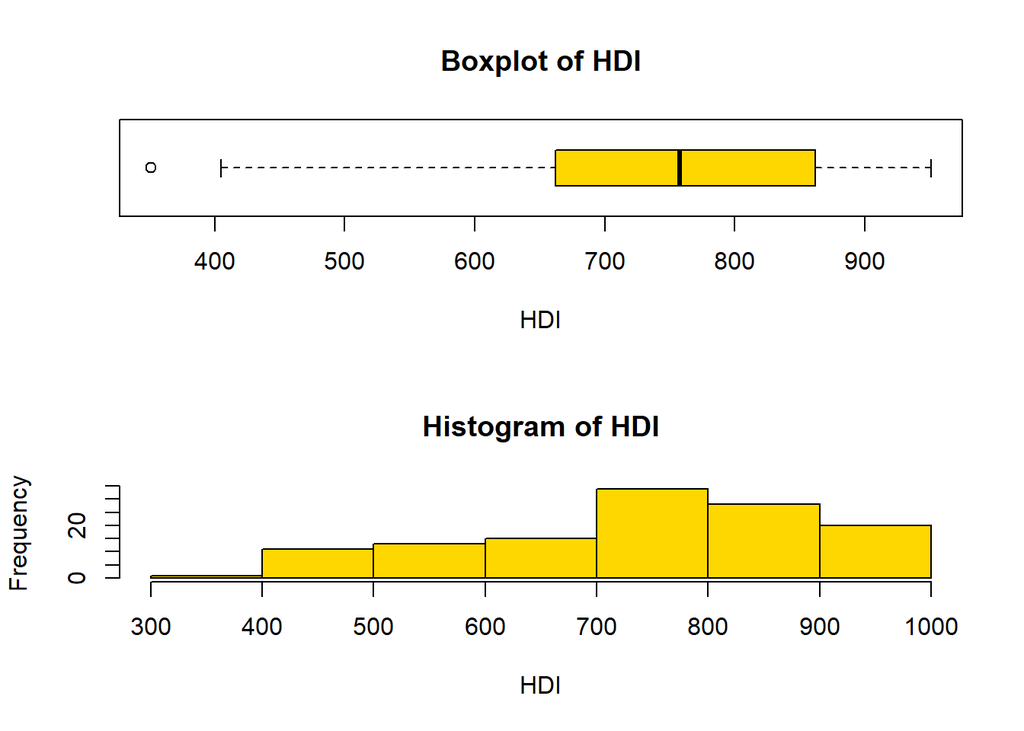

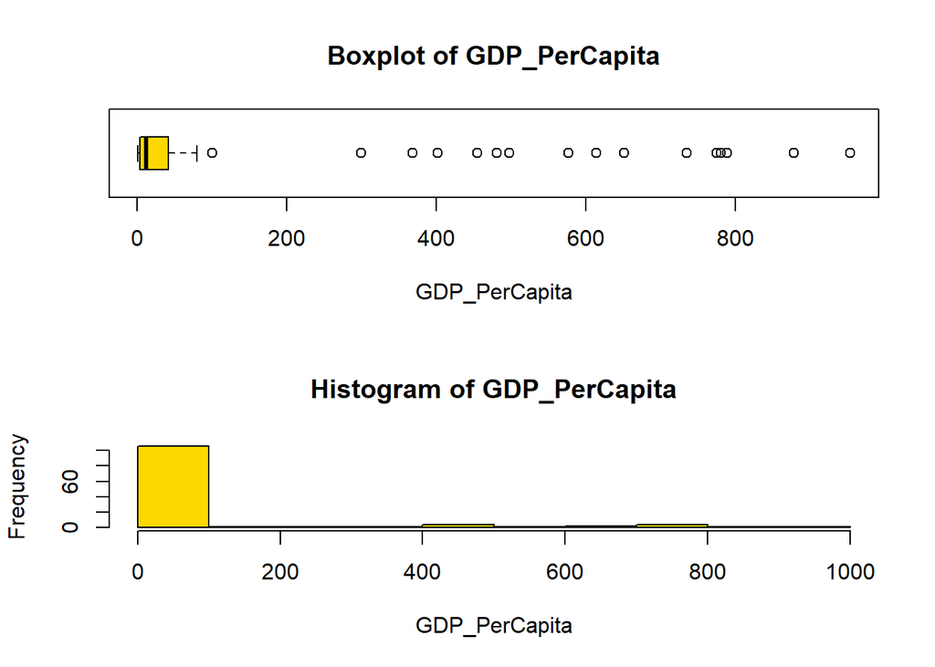

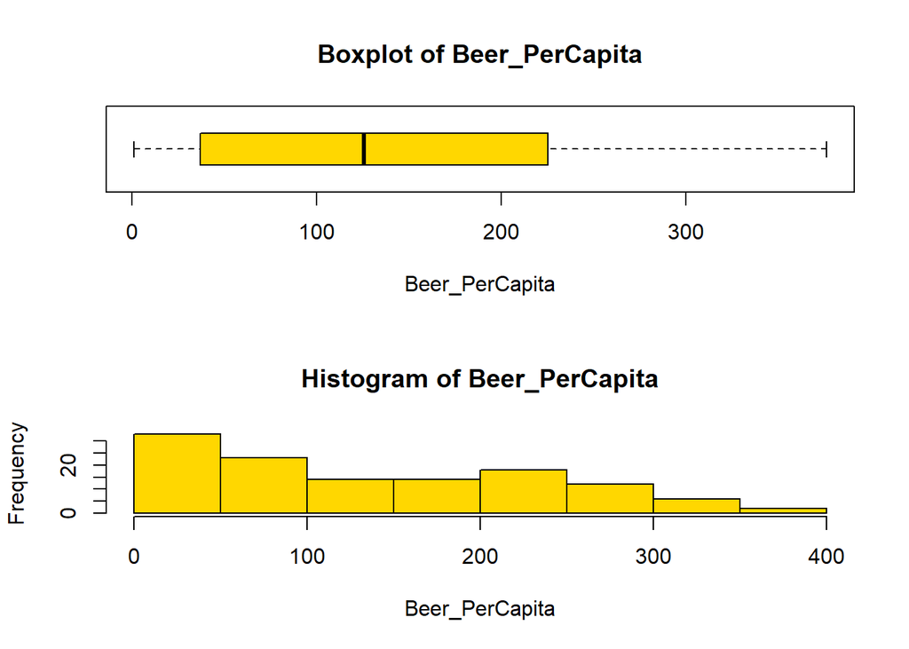

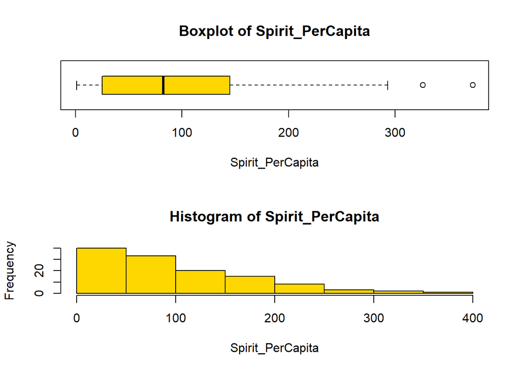

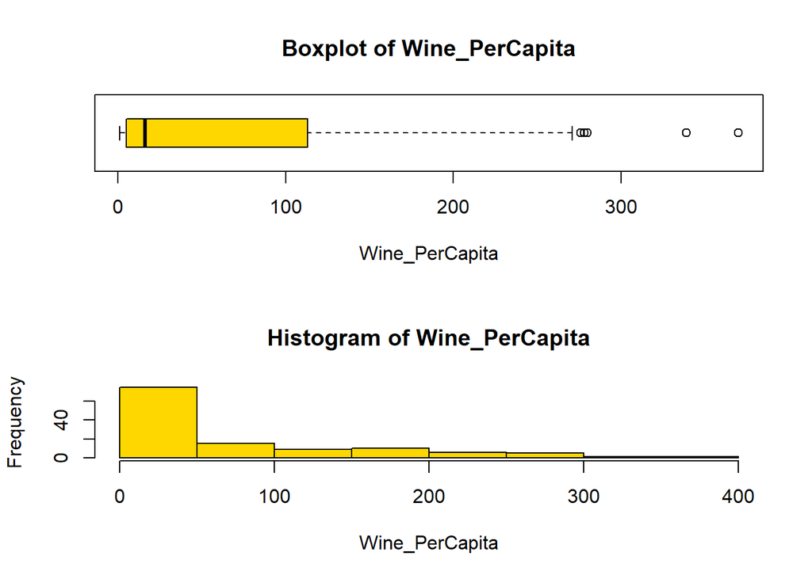

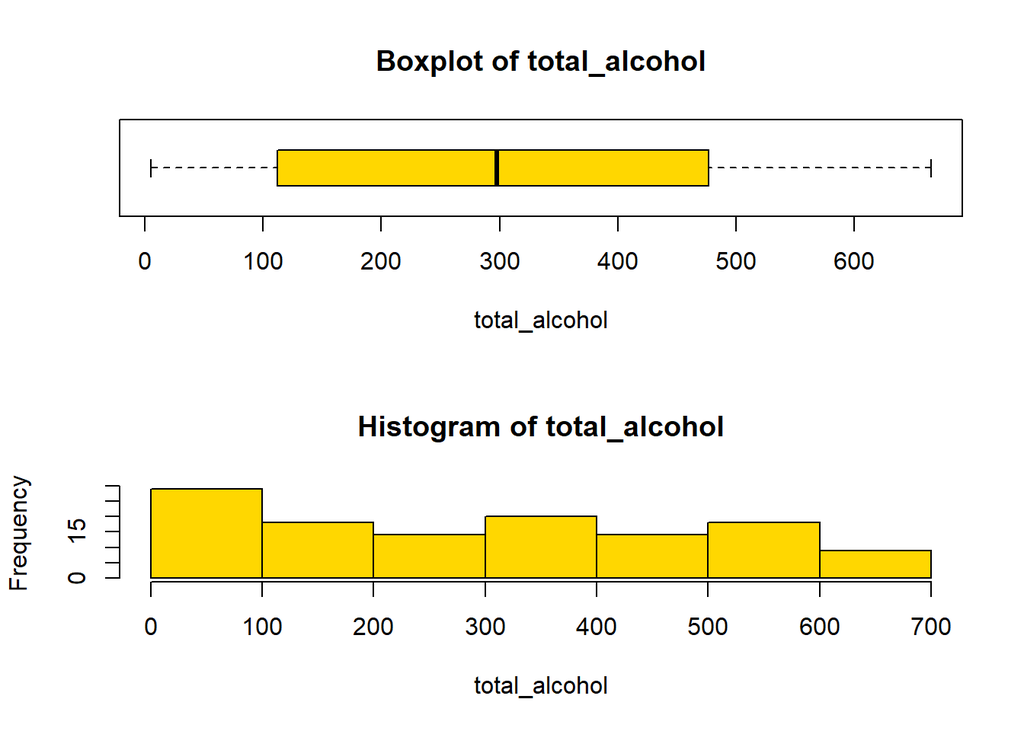

```r
for(i in 1:ncol(df))
  {
    if(is.numeric(df[,i]))
    {
      par(mfrow=c(2,1))
      boxplot(df[,i],main=paste("Boxplot of",names(df)[i]),xlab=names(df)[i] ,horizontal = T, col = 'gold')

      hist(df[,i],main=paste("Histogram of",names(df)[i]),xlab=names(df)[i],col = 'gold')

    }
  }
```

# Observation:- It looks like very few of country that actually has high GDP_PerCapita, also for spirit_PerCapita and wine_PerCapita. i’m afraid some of them will be assume as outlier. Good thing is, Our target variable HappinessScore has normal distribution.